# Chocolate Bar Ratings: EDA

Will Canniford

# Load and clean the data

Firstly, let’s read in the packages that I am going to be using during the analysis.

```r
library(tidyverse)
library(ggplot2)
library(readr)
library(stringr)
library(lubridate)
```

The data here is provided to us in a csv file and kept in the input directory, which is inside the current working directory. I just simply load it here using the `read_csv` function from the `readr` package.

```r
full_data <- read_csv('./input/flavors_of_cacao.csv')
```

Now that we have read in the data we should explore the data set to try and get an understanding about how the data is stored for us.

We can check the dimensions of the data.

```r
dim(full_data)
```

```
## [1] 1796    9
```

We seem to have just under 1,800 observations, or chocolates, and 9 variables. We can check the variables that we have by checking the column names of the data.

```r
names(full_data)
```

```
## [1] "Company \n(Maker-if known)"        "Specific Bean Origin\nor Bar Name"
## [3] "REF"                               "Review\nDate"
## [5] "Cocoa\nPercent"                    "Company\nLocation"
## [7] "Rating"                            "Bean\nType"
## [9] "Broad Bean\nOrigin"
```

If we look at the column names we can see that they contain spaces as well as some line breaks, which definintely isn’t good, so I will remove them using `gsub`.

```r
# Remove and replace spaces and line breaks
names(full_data) <- tolower(gsub(pattern = '[[:space:]+]', '_', names(full_data)))

# View the new column names
names(full_data)
```

```
## [1] "company__(maker-if_known)"        "specific_bean_origin_or_bar_name"
## [3] "ref"                              "review_date"
## [5] "cocoa_percent"                    "company_location"
## [7] "rating"                           "bean_type"
## [9] "broad_bean_origin"
```

That is much more manageable now. I have things about the `janitor` package that deals with things like that, perhaps in a better way so that will be something that I explore in the future.

View the first few rows of the data.

```r
head(full_data)
```

| company__(maker-if_known) | specific_bean_origin_or_bar_name | ref | review_date | cocoa_percent | company_location | rating | bean_type | broad_bean_origin |
| --- | --- | --- | --- | --- | --- | --- | --- | --- |
| (Maker-if known)“ | Specific Bean Origin |  |  |  |  |  |  |  |
| or Bar Name REF Review |  |  |  |  |  |  |  |  |
| Date Cocoa |  |  |  |  |  |  |  |  |
| Percent Company |  |  |  |  |  |  |  |  |
| Location Rating Bean |  |  |  |  |  |  |  |  |
| Type Broad Bean |  |  |  |  |  |  |  |  |
| Origin |  |  |  |  |  |  |  |  |
| A. Morin | Agua Grande | 1876 | 2016 | 63% | France | 3.75 |  | Sao Tome |
| A. Morin | Kpime | 1676 | 2015 | 70% | France | 2.75 |  | Togo |
| A. Morin | Atsane | 1676 | 2015 | 70% | France | 3 |  | Togo |
| A. Morin | Akata | 1680 | 2015 | 70% | France | 3.5 |  | Togo |
| A. Morin | Quilla | 1704 | 2015 | 70% | France | 3.5 |  | Peru |

It looks like the first row of the data is duplicated from the header, so I will remove that as it definitely isn’t an observation.

```r
full_data <- full_data[-1,] # Remove first row
```

Another piece of data cleaning that we should do is remove the *%* sign from the cocoa_percent column. This will mean that we can have the column as numeric, which makes much more sense than having it as a string or category.

```r
# Remove the % sign from the cocoa percent column
full_data$cocoa_percent <- sapply(full_data$cocoa_percent, function(x) gsub("%", "", x))
```

We can now retype the columns to convert the cocoa_percent to a numeric.

```r
# Retype the columns
full_data <- type_convert(full_data)
```

```r
# Have a look at the new data types
map_df(full_data, class)
```

| company__(maker-if_known) | specific_bean_origin_or_bar_name | ref | review_date | cocoa_percent | company_location | rating | bean_type | broad_bean_origin |
| --- | --- | --- | --- | --- | --- | --- | --- | --- |
| character | character | integer | integer | numeric | character | numeric | character | character |

We can convert the year column to a date type using the `lubridate` package.

```r
# Mutate a column that converts the year into a date type
full_data <- full_data %>%
  mutate(review_date = ymd(paste(review_date, 1, 1, sep="-")))
```

We can use the newly created date column that we mutated to create a simple summary table grouping by the year.

```r
avg_ratings <- full_data %>%
  group_by(review_date) %>% # Group by new date column
  summarise(avg_rating = mean(rating), n_ratings = n()) # Summary stats

# Print our new table
avg_ratings
```

| review_date | avg_rating | n_ratings |
| --- | --- | --- |
| 2006-01-01 | 3.125000 | 72 |
| 2007-01-01 | 3.162338 | 77 |
| 2008-01-01 | 2.994624 | 93 |
| 2009-01-01 | 3.073171 | 123 |
| 2010-01-01 | 3.148649 | 111 |
| 2011-01-01 | 3.256061 | 165 |
| 2012-01-01 | 3.178205 | 195 |
| 2013-01-01 | 3.197011 | 184 |
| 2014-01-01 | 3.189271 | 247 |
| 2015-01-01 | 3.246491 | 285 |
| 2016-01-01 | 3.226027 | 219 |
| 2017-01-01 | 3.312500 | 24 |

Here we have created a basic summary table of the average ratings and the number of reviewed observations for each year in the range of our data.

# Insights

## By year

### Faceted distribution of ratings

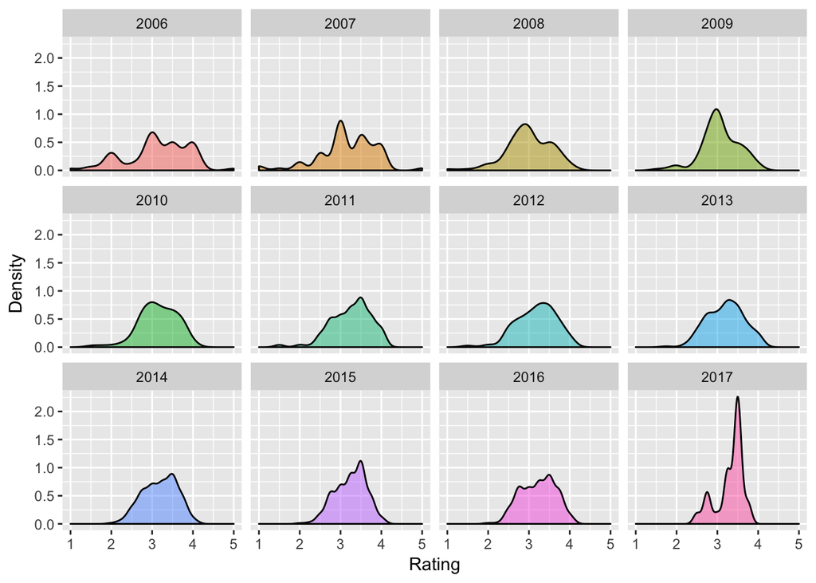

```r
ggplot(full_data, aes(x = rating, fill = as.factor(review_date))) +
  geom_density(alpha = .5) +
  facet_wrap(~ as.factor(year(review_date))) +
  guides(fill = FALSE) + labs(x = 'Rating', y = 'Density')
```

While the peaks throughout the years seems to remain fairly constant, you can see that the most recent year doesn’t have the spread of the first years.  
We can analyse this further by creating a summary table and visualisation while grouping by the year.

### Spread of ratings

```r
standard_deviations <-
  full_data %>% group_by(review_date) %>%
  summarise(count = n(), avg = mean(rating), sd = sd(rating))

standard_deviations
```

| review_date | count | avg | sd |
| --- | --- | --- | --- |
| 2006-01-01 | 72 | 3.125000 | 0.7691224 |
| 2007-01-01 | 77 | 3.162338 | 0.6998193 |
| 2008-01-01 | 93 | 2.994624 | 0.5442118 |
| 2009-01-01 | 123 | 3.073171 | 0.4591195 |
| 2010-01-01 | 111 | 3.148649 | 0.4663426 |
| 2011-01-01 | 165 | 3.256061 | 0.4899536 |
| 2012-01-01 | 195 | 3.178205 | 0.4835962 |
| 2013-01-01 | 184 | 3.197011 | 0.4461178 |
| 2014-01-01 | 247 | 3.189271 | 0.4148615 |
| 2015-01-01 | 285 | 3.246491 | 0.3810960 |
| 2016-01-01 | 219 | 3.226027 | 0.4205809 |
| 2017-01-01 | 24 | 3.312500 | 0.3317444 |

We seem to see that the standard deviation of rating seems to be decreasing as time passes. This is more clearly seen when you visualise the trend.

I have included the number of reviews per year here using the `size` aesthetic of `geom_point` to give an idea of the sample size for each year as time passes.

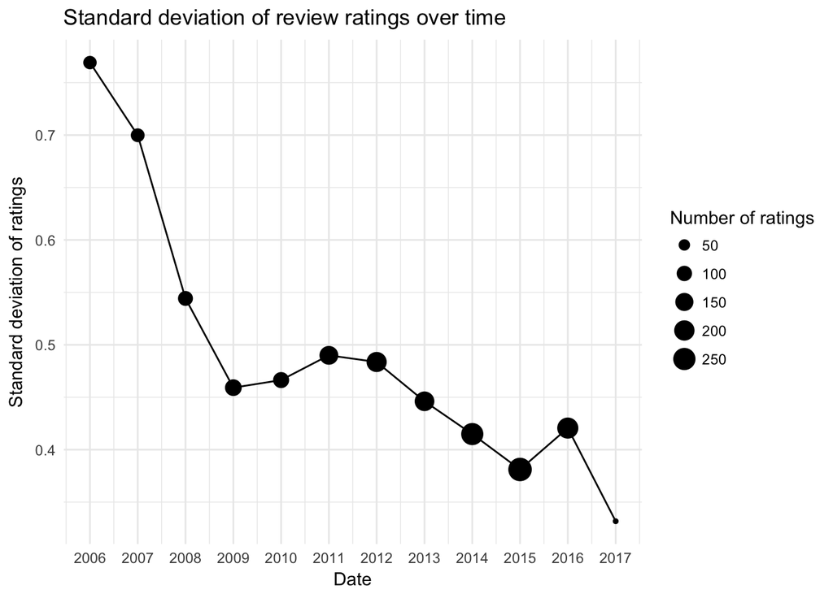

```r
standard_deviations %>% # Use our previous summary table
  ggplot(aes(review_date, sd)) +
  geom_point(aes(size = count)) + # Change point size depending on number of reviews
  geom_line(size = .5) +
  theme_minimal() +
  scale_x_date(date_breaks = '1 year', date_labels = '%Y') +
  scale_size(breaks = seq(0,250,50), name = 'Number of ratings') +
  labs(x = 'Date',
       y = 'Standard deviation of ratings',
       title = 'Standard deviation of review ratings over time')
```

Upon visualisation of the data we can see that 2017 might simply have a smaller spread due to the smaller number of ratings that have been taken in that year. As the number of ratings taken in the year increases, we say see it rise to near that of the previous 6/7 years, although there does appear to be a definite downward trend, implying that reviewers are giving less extreme scores.

### Extreme ratings

```r
low_scores <- full_data %>%
  group_by(review_date) %>%
  summarise(less_than_2.5 = sum(rating < 2.5), count = n(), perc = round(less_than_2.5 / count, 2))

low_scores
```

| review_date | less_than_2.5 | count | perc |
| --- | --- | --- | --- |
| 2006-01-01 | 13 | 72 | 0.18 |
| 2007-01-01 | 7 | 77 | 0.09 |
| 2008-01-01 | 7 | 93 | 0.08 |
| 2009-01-01 | 6 | 123 | 0.05 |
| 2010-01-01 | 5 | 111 | 0.05 |
| 2011-01-01 | 5 | 165 | 0.03 |
| 2012-01-01 | 6 | 195 | 0.03 |
| 2013-01-01 | 4 | 184 | 0.02 |
| 2014-01-01 | 5 | 247 | 0.02 |
| 2015-01-01 | 3 | 285 | 0.01 |
| 2016-01-01 | 2 | 219 | 0.01 |
| 2017-01-01 | 0 | 24 | 0.00 |

Having a closer look, by year, at the reviews that were given a rating of less than 2.5, you can clearly see that the number of those poor scores is going down, despite the number of reviews going up! 18% of reviews in 2006 (13/72) where less than 2.5, while only 5 reviews fell below that threshold since 2015!

Once again, plotting this trend makes it much easier to digest.

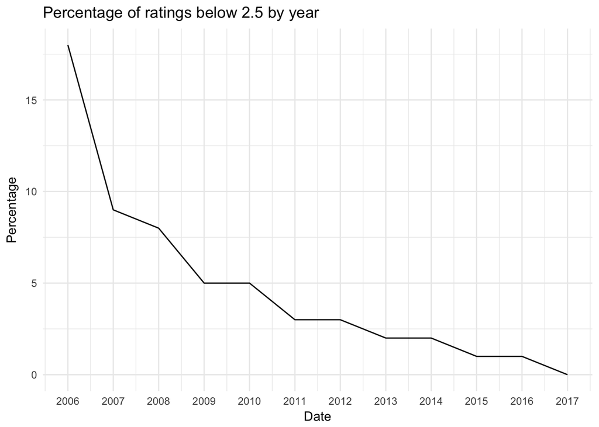

```r
low_scores %>%
  ggplot() + geom_line(aes(review_date, perc * 100)) +
  theme_minimal() +
  scale_x_date(date_breaks = '1 year', date_labels = '%Y') +
  labs(x = 'Date',
       y = 'Percentage',
       title = 'Percentage of ratings below 2.5 by year')
```

### Frequent ratings over time

So we have established that the spread of the ratings is getting smaller, and reviewers are giving less low scores below 2.5.

We can further visualise these features of the data by exploring other plots.

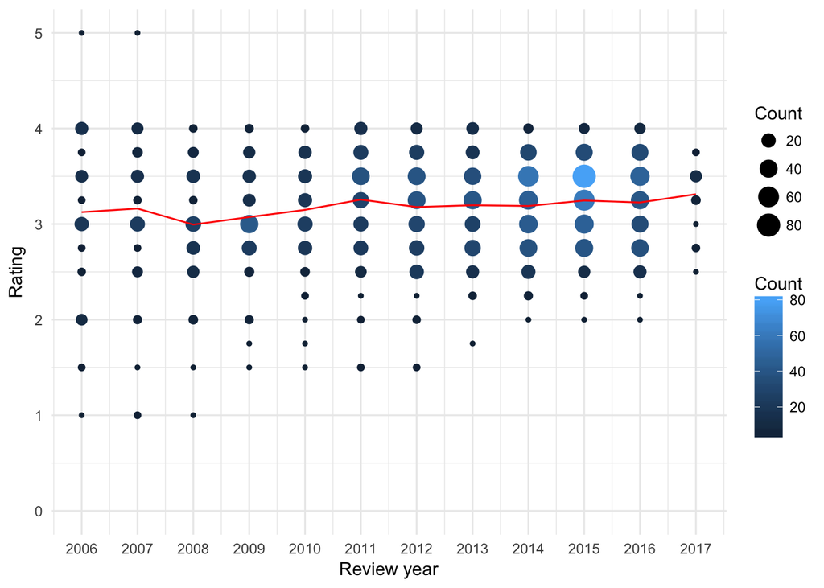

```r
full_data %>%
  ggplot(aes(review_date, rating)) +
  geom_count(aes(colour = ..n..)) +
  geom_line(data = avg_ratings, aes(review_date, avg_rating), colour = 'red') + # Use average ratings table from earlier
  scale_x_date(date_breaks = '1 year', date_labels = '%Y') +
  scale_size_continuous(name = 'Count') + scale_color_continuous(name = 'Count') +
  expand_limits(y = 0) + # Expand limits to include 0
  theme_minimal() +
  labs(x = 'Review year', y = 'Rating')
```

We can see that the spread of the reviews is definitely narrowing, with the lower tail retracting and reviews now generally falling between 3 and 4 in 2015 onwards.

## Companies and Makers

### Company location

We can investigate whether the location of the company has an impact on the quality of the product.

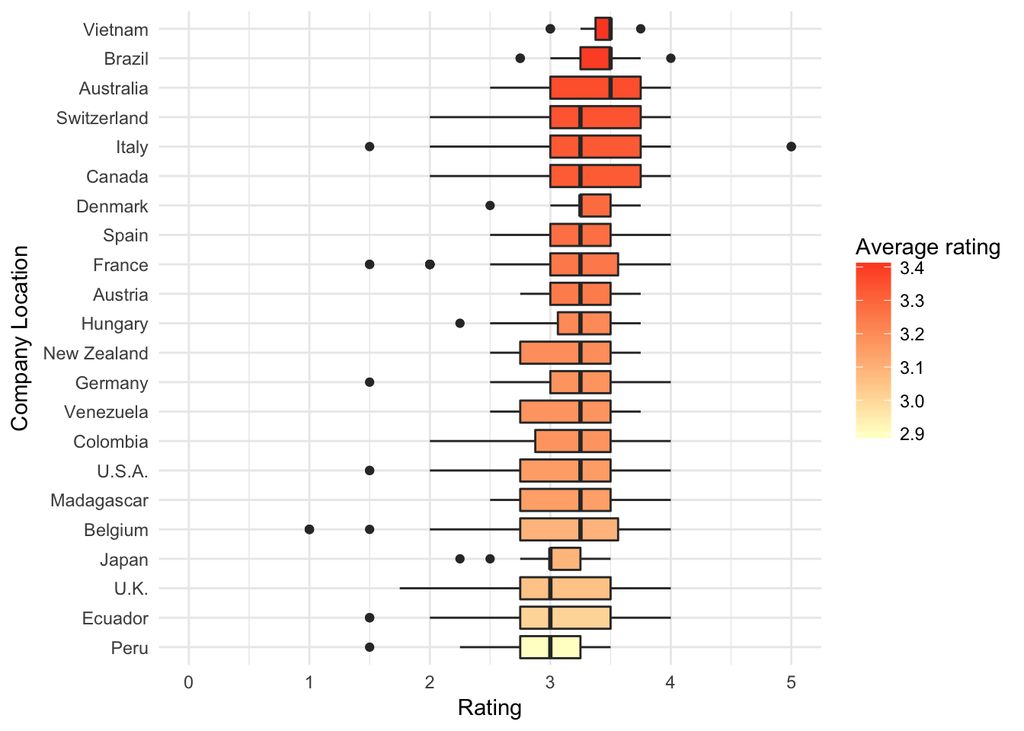

```r
full_data %>%
  group_by(company_location) %>%
  filter(n() > 10) %>%
  mutate(avg = mean(rating)) %>%
  ggplot() +
  geom_boxplot(aes(reorder(company_location, avg), rating, fill = avg)) +
  scale_fill_continuous(low = '#ffffcc', high = '#fc4e2a', name = "Average rating") +
  coord_flip() +
  theme_minimal() +
  labs(x = 'Company Location', y = 'Rating') +
  expand_limits(y = c(0,5))
```

### Master makers

As the column in the data is company/maker, I will extract the maker so that we can compare the makers against one another to see if there are any master makers hidden in the data.

Once I have split the company and maker from the column then I will select those makers that have at least 3 reviewed products.

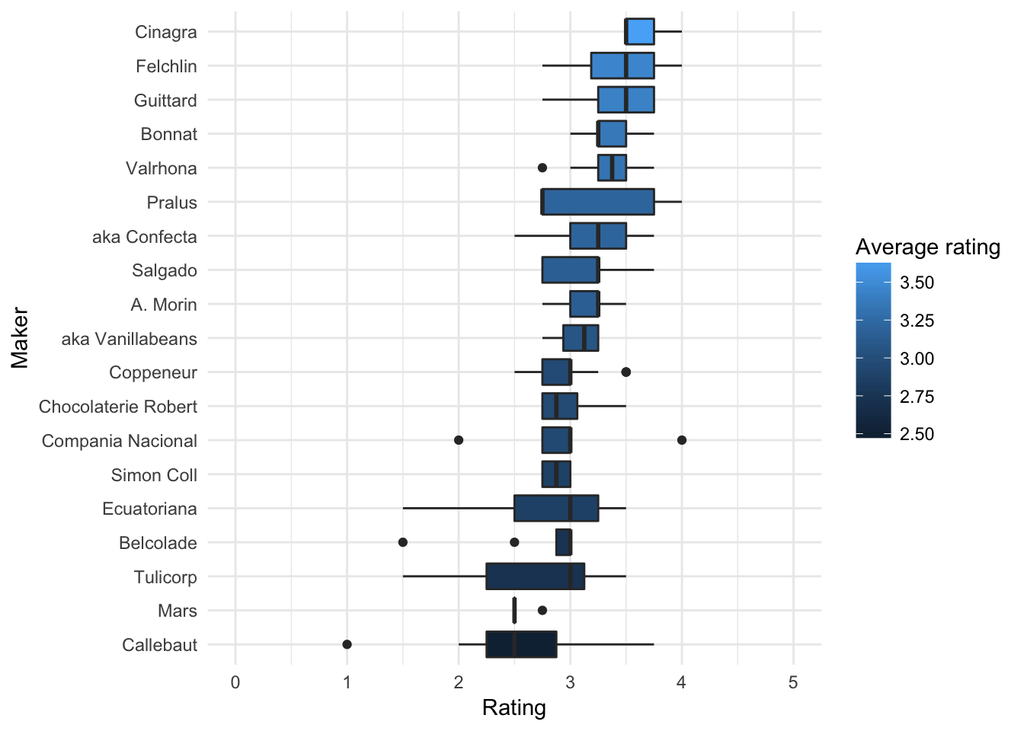

```r
colnames(full_data)[1] <- 'company_maker'
makers <- full_data %>%
  rowwise %>%
  mutate(maker = str_match(company_maker, '\\((.*)\\)')[2]) %>%
  filter(!is.na(maker)) %>% # If a maker was noted
  group_by(maker) %>% # Grouping
  filter(n() >= 3) %>% # Minimum product filter
  mutate(avg = mean(rating)) # Get average rating

ggplot(makers) +
  geom_boxplot(aes(x = reorder(maker, rating, FUN = mean), y = rating, fill = avg)) +
  labs(x = 'Maker', y = 'Rating') +
  coord_flip() +
  theme_minimal() +
  scale_fill_continuous(name = "Average rating") +
  expand_limits(y = c(0,5))
```

It appears as those *Cinagra* is our master chocolatier.

### Company records over time

I split the company/maker column again, this time selecting the company, and filter by those with at least 10 reviews.

```r
companies <- full_data %>%
  rowwise() %>%
  mutate(company = str_trim(str_split(company_maker, '\\(')[[1]][1])) %>%
  group_by(company) %>%
  filter(n() > 10) %>%
  mutate(avg = mean(rating))
```

By plotting the count of reviews for ratings using the `size` aesthetic again, we are also able to see the distribution of scores for the companies.

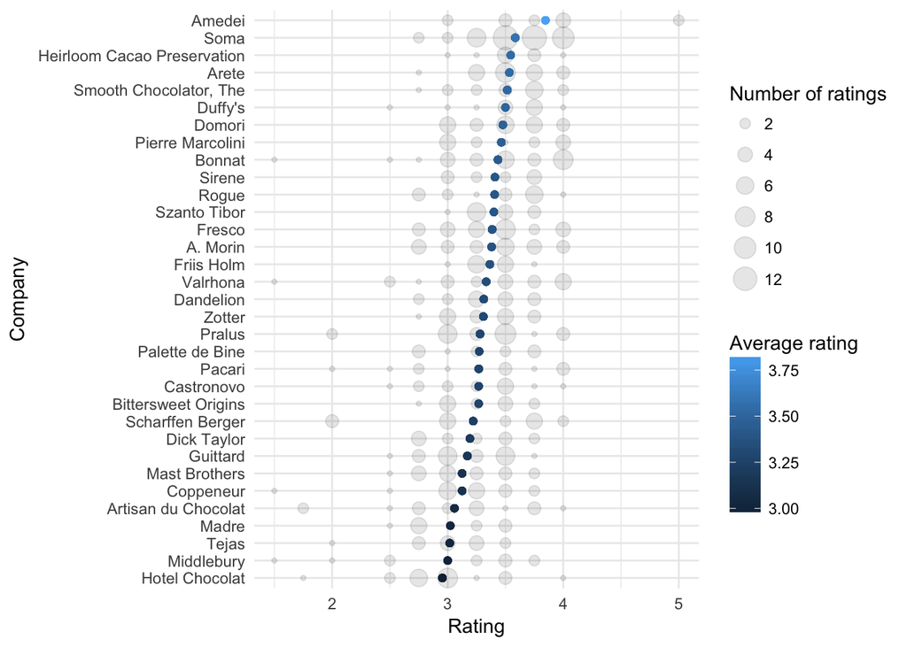

```r
companies  %>%
  ggplot(aes(x = reorder(as.factor(company), rating, FUN = mean), y = rating)) +
  geom_count(alpha = .1) +
  geom_point(aes(x = as.factor(company), y = avg, colour = avg)) +
  theme_minimal() +
  coord_flip() +
  labs(x = 'Company', y = 'Rating') +
  scale_color_continuous(name = 'Average rating', breaks = seq(3,4,.25)) +
  scale_size_continuous(name = 'Number of ratings', breaks = seq(0,14,2))
```

This gives us an overview of companies overall, but doesn’t show us trends for those companies over time. We can investigate that using `facet_wrap` and plotting against the `review_date`.

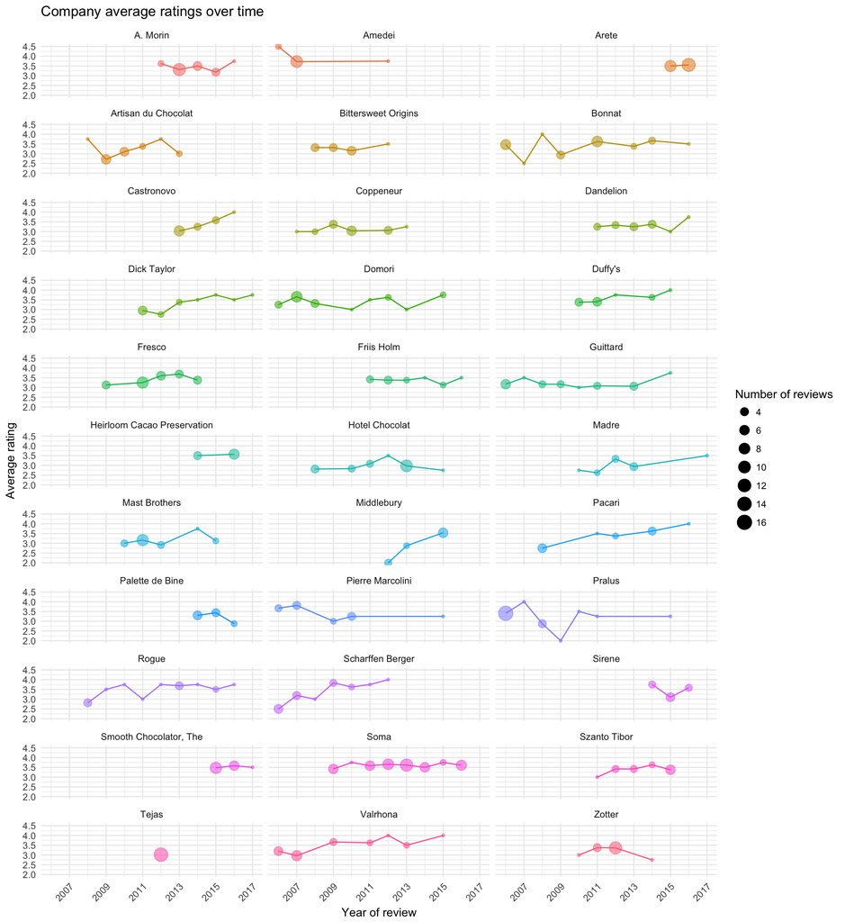

```r
# Which of these companies are improving
full_data %>%
  rowwise() %>%
  mutate(company = str_trim(str_split(company_maker, '\\(')[[1]][1])) %>%
  group_by(company) %>%
  filter(n() > 10) %>%
  group_by(company, review_date) %>%
  summarise(count = n(), avg = mean(rating)) %>%
  ungroup() %>%
  ggplot() +
    geom_point(aes(x = review_date, y = avg, size = count, colour = as.factor(company), alpha = 0.05)) +
    geom_line(aes(x = review_date, y = avg, colour = as.factor(company))) +
    facet_wrap(~ company, ncol = 3) +
    scale_x_date(date_labels = '%Y', date_breaks = '2 year') +
    theme_minimal() +
    theme(axis.text.x = element_text(angle = 45, hjust = 1)) +
    guides(colour = FALSE) +
  labs(x = 'Year of review', y = 'Average rating', title = "Company average ratings over time") +
    scale_size_continuous(breaks = seq(4, 16, 2), name = 'Number of reviews') +
    scale_alpha(guide = F)
```

Some appear to have shown improvements, but such increases can probably just be put down to small number of reviews for a given year. To see whether the company is truly improving we would require a greater number of product reviews for the current year.

## Cocoa percent

Let’s investigate to see whether there is a relationship between cocoa percentage and the chocolate’s rating.

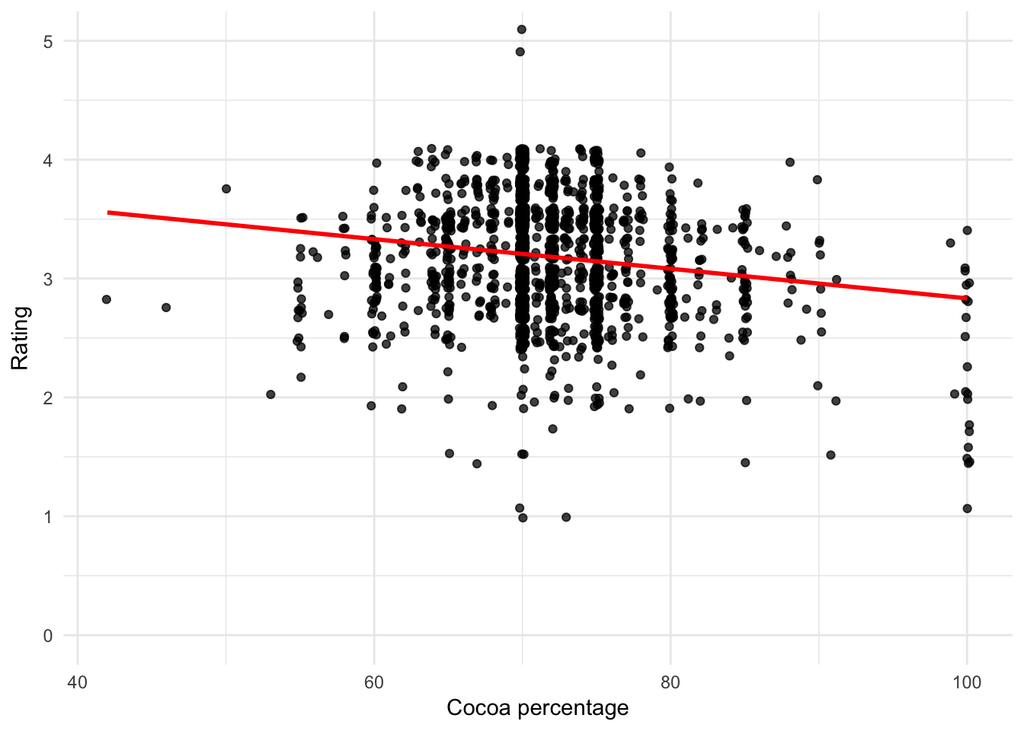

```r
full_data %>%
  ggplot(aes(x = cocoa_percent, y = rating)) +
  geom_jitter(alpha = .75) +
  coord_cartesian(ylim = c(0,5)) +
  labs(x = 'Cocoa percentage', y = 'Rating') +
  theme_minimal() +
  geom_smooth(method = 'lm', se = FALSE, col = 'red')
```

There doesn’t appear to be a strong relationship between cocoa percent and rating here. Let’s have a look at the model separately.

```r
model <- lm(formula = rating ~ cocoa_percent,
            data = full_data)

summary(model)
```

```
##
## Call:
## lm(formula = rating ~ cocoa_percent, data = full_data)
##
## Residuals:
##     Min      1Q  Median      3Q     Max
## -2.2071 -0.3196  0.0429  0.3178  1.7929
##
## Coefficients:
##                Estimate Std. Error t value Pr(>|t|)
## (Intercept)    4.079388   0.126757  32.183  < 2e-16 ***
## cocoa_percent -0.012461   0.001761  -7.076 2.12e-12 ***
## ---
## Signif. codes:  0 '***' 0.001 '**' 0.01 '*' 0.05 '.' 0.1 ' ' 1
##
## Residual standard error: 0.4717 on 1793 degrees of freedom
## Multiple R-squared:  0.02717,    Adjusted R-squared:  0.02662
## F-statistic: 50.07 on 1 and 1793 DF,  p-value: 2.122e-12
```

With an adjusted R-squared of 0.02662 it is fair to say that this isn’t a very good model, but there is a relationship between the rating and the cocoa_percent, it just isn’t the most informative. The negative slope implies to us that the higher the cocoa_percent then the lower the rating of the chocolate.

If we were going to build a model to predict the rating of the chocolate then we would definitely have to take more variables into consideration.

### Considering time with predictions

We have already seen the impact that time has had on predictions. We can see that the spread of the ratings has decreased as time has passed. Perhaps factoring this into consideration will help us improve our prediction power.

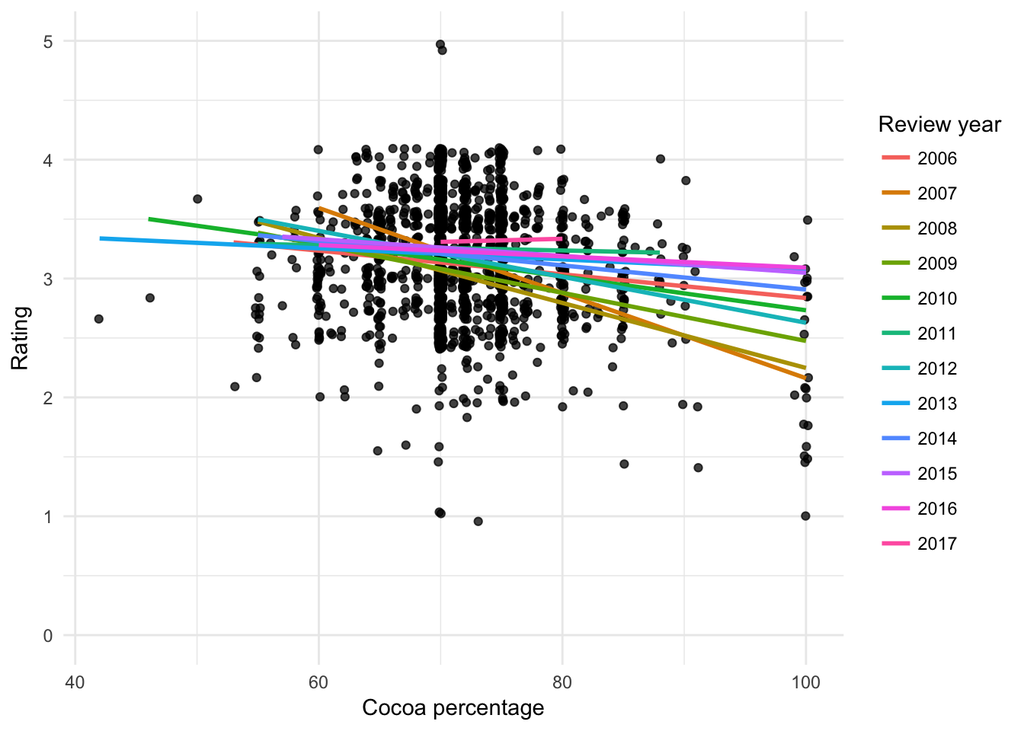

```r
ggplot(full_data, aes(x = cocoa_percent, y = rating, group = factor(year(review_date)))) +
  geom_jitter(alpha = .75) +
  coord_cartesian(ylim = c(0,5)) +
  labs(x = 'Cocoa percentage', y = 'Rating') +
  theme_minimal() +
  geom_smooth(method = 'lm', se = FALSE, aes(colour = factor(year(review_date)))) +
  scale_colour_discrete(name = 'Review year')
```

We can see how the slope of the line changes each year. Let’s see how adding year to the linear predictor impacts the quality of our model.

```r
model <- lm(formula = rating ~ cocoa_percent + factor(year(review_date)),
            data = full_data)

summary(model)
```

```
##
## Call:
## lm(formula = rating ~ cocoa_percent + factor(year(review_date)),
##     data = full_data)
##
## Residuals:
##      Min       1Q   Median       3Q      Max
## -2.18813 -0.27847  0.02432  0.30320  1.86235
##
## Coefficients:
##                                Estimate Std. Error t value Pr(>|t|)
## (Intercept)                    4.023050   0.136368  29.501  < 2e-16 ***
## cocoa_percent                 -0.012649   0.001756  -7.201 8.76e-13 ***
## factor(year(review_date))2007  0.050479   0.076772   0.658   0.5109
## factor(year(review_date))2008 -0.108887   0.073552  -1.480   0.1389
## factor(year(review_date))2009 -0.058873   0.069477  -0.847   0.3969
## factor(year(review_date))2010  0.020857   0.070844   0.294   0.7685
## factor(year(review_date))2011  0.130677   0.066125   1.976   0.0483 *
## factor(year(review_date))2012  0.059886   0.064568   0.927   0.3538
## factor(year(review_date))2013  0.088028   0.065118   1.352   0.1766
## factor(year(review_date))2014  0.080120   0.062741   1.277   0.2018
## factor(year(review_date))2015  0.134317   0.061777   2.174   0.0298 *
## factor(year(review_date))2016  0.110615   0.063614   1.739   0.0822 .
## factor(year(review_date))2017  0.194351   0.110352   1.761   0.0784 .
## ---
## Signif. codes:  0 '***' 0.001 '**' 0.01 '*' 0.05 '.' 0.1 ' ' 1
##
## Residual standard error: 0.4682 on 1782 degrees of freedom
## Multiple R-squared:  0.04739,    Adjusted R-squared:  0.04097
## F-statistic: 7.387 on 12 and 1782 DF,  p-value: 2.096e-13
```

This shows us that some of the years have a ‘signficant’ impact on the response variable, but overall the impact isn’t as substantial as we might hope for.

We can note that the R-squared value has risen from **0.02662** to **0.04097** so it is in the right direction but still pretty awful.

## Broad bean origin

Let’s have a look at the unique origins that are listed in the dataset. This is easily achieved using the `unique` function.

```r
# Look at unique origins
unique(full_data$broad_bean_origin)
```

```
##   [1] "Sao Tome"                      "Togo"
##   [3] "Peru"                          "Venezuela"
##   [5] "Cuba"                          "Panama"
##   [7] "Madagascar"                    "Brazil"
##   [9] "Ecuador"                       "Colombia"
##  [11] "Burma"                         "Papua New Guinea"
##  [13] "Bolivia"                       "Fiji"
##  [15] "Mexico"                        "Indonesia"
##  [17] "Trinidad"                      "Vietnam"
##  [19] "Nicaragua"                     "Tanzania"
##  [21] "Dominican Republic"            "Ghana"
##  [23] "Belize"                        " "
##  [25] "Jamaica"                       "Grenada"
##  [27] "Guatemala"                     "Honduras"
##  [29] "Costa Rica"                    "Domincan Republic"
```

[output cut: 36 more lines]

Since we are looking at the broad bean origin during this part of the analysis we are going to want to remove those rows that don’t appear to have a known bean origin.  
Using the unique values above we are able to look through the origins that are included in the data set and use that information to filter all the observations accordingly.

```r
beans <- full_data %>%
    filter(!is.na(broad_bean_origin),     # Remove those with NA values
           !nchar(broad_bean_origin) < 2) # Remove those where the origin is too short to be a realistic palce
```

### Most frequent bean origin

Now that we have filtered the data (`beans`) to include just those observations with broad bean origins we are able to working out which origins occur the most frequently, or are the most widely used in these chocolates.

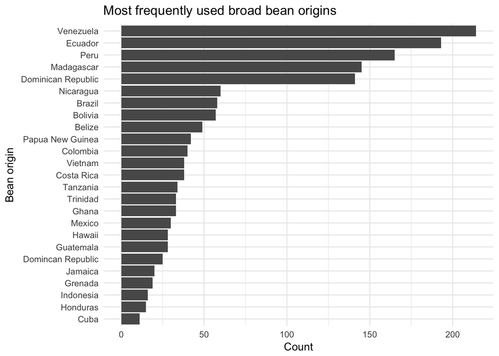

```r
# Most frequent broad bean origin
beans %>%
  group_by(broad_bean_origin) %>% # Group by origin
  filter(n() > 10) %>% # Limit to those with at least 10 observations
  mutate(count = n()) %>% # Add the count column
  ggplot(aes(x = reorder(broad_bean_origin, count))) +
  geom_bar() +
  coord_flip() +
  theme_minimal() +
  labs(x = 'Bean origin', y = 'Count', title = 'Most frequently used broad bean origins')
```

Looking at this simple graph we are able to see that the most popular broad bean origins are Venezuela, Ecuador and Peru. Madagascar, probably more famous for its vanilla, is in fourth place.

### Origin and ratings

*Does the origin of the bean have a noticeable impact on the rating of the chocolate?*  
We can visualise the answer to this question by looking at the statistics of the ratings when they are grouped by their broad bean origin.

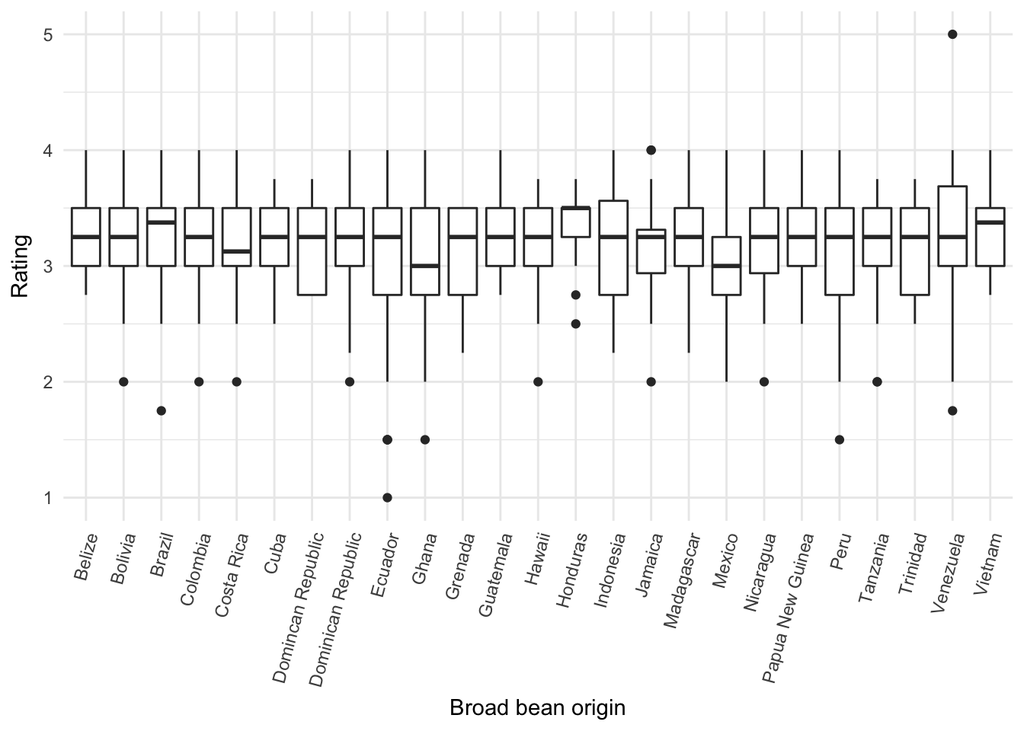

```r
beans %>%
  group_by(broad_bean_origin) %>%
  filter(n() > 10) %>% # Keep only those with more than 10 observations
  mutate(count = n()) %>%
  ggplot() +
  geom_boxplot(aes(x = broad_bean_origin, y = rating)) +
  theme_minimal() +
  theme(axis.text.x = element_text(angle = 75, hjust = 1)) +
  labs(x = 'Broad bean origin', y = 'Rating')
```

Having seen the boxplot, we can see that there doesn’t appear to be any relationship between broad bean origin and rating. The company or the maker that is producing the product itself must be a more important indicator of the overall rating of the chocolate.

### Companies and bean origin heatmap

We can use the subset which contains only the companies with the most observations to generate a heatmap showing the interactions between company and broad bean origin.

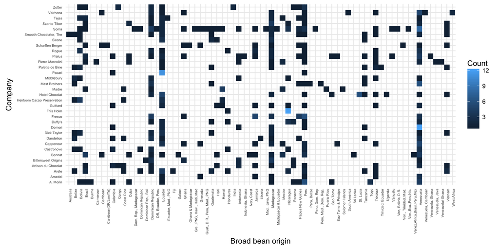

```r
companies %>%
  filter(!is.na(broad_bean_origin), !nchar(broad_bean_origin) < 2) %>%
  group_by(company, broad_bean_origin) %>%
  summarise(count = n()) %>%
  filter(count > 0) %>%
  ggplot() +
  geom_tile(aes(broad_bean_origin, company, fill = count)) +
  coord_equal() +
  scale_fill_continuous(name = 'Count') +
  theme_minimal() +
  theme(axis.text.x = element_text(angle = 90, hjust = 1, size = 5)) +
  theme(axis.text.y = element_text(size = 5)) +
  labs(x = 'Broad bean origin', y = 'Company')
```

We can see that there are only a few bright spots on what is a quite busy plot. The popular locations for broad bean origin make the vertical straight lines on the plot.  
You can see clear vertical lines at Venezuela, Peru and Ecuador as we would expect.

# Conclusions

- Over time the average rating isn’t increasing but the instances of extreme ratings is descreasing, resulting in a smaller spread of ratings
- The country of manufacter doesn’t appear to have a large impact on rating, but both the maker and company can be seen to impact the average rating of a chocolate
- There isn’t a strong relationship between the cocoa percent and rating of the chocolate. Fitting a linear model showed us that we would need to include more features to build a good prediction model
  - The addition of year to the model as a factor improved the model, but it is still poor
- Broad bean origin seems to be well represented by *the big five*:
  - Venezuela
  - Ecuador
  - Peru
  - Madagascar
  - Dominican Republic
- However, the broad bean origin of the bean doesn’t seem to determine the quality, or rating, of the chocolate

Thanks for taking the time to have a look at my analysis and visualisations, if you enjoyed it or learned something then please feel free to upvote the kernel ;)  
I am still looking to improve this kernel and would greatly appreciate any feedback or advice that you could share with me.